# R Notebook

# Importing the data

Read the raw counts using code from previous session

```r
library(tximport)
library(DESeq2)
dirs <- list.files(file.path("salmon_quant/"))
quant_files <- paste0("salmon_quant/",dirs,"/quant.sf.gz")
names(quant_files) <- dirs

tx2gene <- read.csv("tx2gene.csv")

txi <- tximport(quant_files,type="salmon",tx2gene = tx2gene,ignoreTxVersion = TRUE)
```

```
reading in files with read_tsv
1 2 3 4 5 6 7 8 9 10 11 12
transcripts missing from tx2gene: 147
summarizing abundance
summarizing counts
summarizing length
```

```r
sampleinfo <- read.delim("meta_data/sampleInfo_corrected.txt")
rownames(sampleinfo) <- sampleinfo$run

dds <- DESeqDataSetFromTximport(txi,
                                colData = sampleinfo,
                                design <- ~CellType)
```

```
some variables in design formula are characters, converting to factorsusing counts and average transcript lengths from tximport
```

Analyse the default factor of `CellType` to compare `basal` and `luminal` cell types.

```r
de_status <- DESeq(dds)
```

```
using 'avgTxLength' from assays(dds), correcting for library size
```

We can use `dplyr` to transform into a more manageable data frame

```r
library(dplyr)
library(tibble)
results_cellType <- results(de_status) %>%
  as.data.frame %>%
  rownames_to_column("ENSEMBL")

results_cellType
```

| ENSEMBL | baseMean | log2FoldChange | lfcSE | stat | pvalue | padj |
| --- | --- | --- | --- | --- | --- | --- |
| ENSMUSG00000000001 | 4.068373e+03 | 0.385573661 | 0.14221259 | 2.71124841 | 6.703039e-03 | 1.618258e-02 |
| ENSMUSG00000000003 | 0.000000e+00 | NA | NA | NA | NA | NA |
| ENSMUSG00000000028 | 2.035125e+02 | 0.811093671 | 0.42792802 | 1.89539745 | 5.803977e-02 | 1.061702e-01 |
| ENSMUSG00000000037 | 1.212774e+02 | -1.790710525 | 0.32576077 | -5.49701092 | 3.862828e-08 | 2.568220e-07 |
| ENSMUSG00000000049 | 2.099996e+00 | -1.664249344 | 1.20038630 | -1.38642813 | 1.656162e-01 | 2.559862e-01 |
| ENSMUSG00000000056 | 4.371347e+02 | 0.045812931 | 0.33740407 | 0.13578061 | 8.919947e-01 | 9.258617e-01 |
| ENSMUSG00000000058 | 3.647180e+03 | 0.145598500 | 0.49912190 | 0.29170930 | 7.705089e-01 | 8.374654e-01 |
| ENSMUSG00000000078 | 3.598097e+04 | 0.755845507 | 0.26230242 | 2.88158041 | 3.956863e-03 | 1.013386e-02 |
| ENSMUSG00000000085 | 6.957512e+02 | -1.789986700 | 0.39501192 | -4.53147510 | 5.857324e-06 | 2.694721e-05 |
| ENSMUSG00000000088 | 2.488367e+03 | 1.502068062 | 0.28605031 | 5.25106257 | 1.512243e-07 | 9.148244e-07 |

[output cut: 990 more lines]

# Exercise

We now want to use the `Status` as our factor of interest. This can be achieved by changing the `design` our object

```r
dds_status <- dds
colData(dds)
```

```
DataFrame with 12 rows and 4 columns
                   run        Name CellType      Status
           <character> <character> <factor> <character>
SRR1552444  SRR1552444     MCL1-LA  luminal      virgin
SRR1552445  SRR1552445     MCL1-LB  luminal      virgin
SRR1552446  SRR1552446     MCL1-LC  luminal   pregnancy
SRR1552447  SRR1552447     MCL1-LD  luminal   pregnancy
SRR1552448  SRR1552448     MCL1-LE  luminal   lactation
...                ...         ...      ...         ...
SRR1552451  SRR1552451     MCL1-DH    basal      virgin
SRR1552452  SRR1552452     MCL1-DI    basal   pregnancy
SRR1552453  SRR1552453     MCL1-DJ    basal   pregnancy
SRR1552454  SRR1552454     MCL1-DK    basal   lactation
SRR1552455  SRR1552455     MCL1-DL    basal   lactation
```

```r
dds_status$Status <- as.factor(dds_status$Status)
design(dds_status) <- ~Status
de_status <- DESeq(dds_status)
```

```
using 'avgTxLength' from assays(dds), correcting for library size
```

The default contrast is already virgin vs lactation. As above we can create a data frame for further processing.

```r
results_status <- results(de_status) %>%
  as.data.frame %>%
  rownames_to_column("ENSEMBL")

results_status
```

| ENSEMBL | baseMean | log2FoldChange | lfcSE | stat | pvalue | padj |
| --- | --- | --- | --- | --- | --- | --- |
| ENSMUSG00000000001 | 4.068373e+03 | 1.649780e-01 | 0.19952495 | 0.826853883 | 4.083199e-01 | 7.030911e-01 |
| ENSMUSG00000000003 | 0.000000e+00 | NA | NA | NA | NA | NA |
| ENSMUSG00000000028 | 2.035125e+02 | 8.726125e-02 | 0.63706521 | 0.136973805 | 8.910515e-01 | 9.657905e-01 |
| ENSMUSG00000000037 | 1.212774e+02 | -7.692290e-02 | 0.76280840 | -0.100841705 | 9.196761e-01 | 9.744969e-01 |
| ENSMUSG00000000049 | 2.099996e+00 | 7.427571e-01 | 1.24447861 | 0.596841995 | 5.506129e-01 | NA |
| ENSMUSG00000000056 | 4.371347e+02 | -3.208021e-01 | 0.43688055 | -0.734301672 | 4.627649e-01 | 7.474356e-01 |
| ENSMUSG00000000058 | 3.647180e+03 | -1.580262e+00 | 0.37350230 | -4.230929372 | 2.327277e-05 | 8.099477e-04 |
| ENSMUSG00000000078 | 3.598097e+04 | -7.101779e-01 | 0.39639899 | -1.791573469 | 7.320132e-02 | 2.762107e-01 |
| ENSMUSG00000000085 | 6.957512e+02 | -5.739640e-02 | 0.78576644 | -0.073045119 | 9.417702e-01 | 9.812286e-01 |
| ENSMUSG00000000088 | 2.488367e+03 | -9.457339e-01 | 0.61051860 | -1.549066513 | 1.213657e-01 | 3.699028e-01 |

[output cut: 990 more lines]

```r
saveRDS("Robjects/results_status.rds")
```

```
Error in saveRDS("Robjects/results_status.rds") :
  'file' must be non-empty string
```

We can filter to discover differentially-expressed genes and write out to a file

```r
library(readr)
results_status %>% filter(abs(log2FoldChange) > 1, padj < 0.05) %>%
  write_csv("virgin_vs_lactation_DE.csv")
```

# Exercise

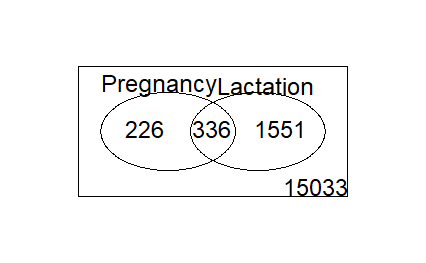

```r
library(limma)
results_p_vs_v <- results(de_status, contrast = c("Status","pregnancy","virgin")) %>%
    as.data.frame %>%
  rownames_to_column("ENSEMBL")

results_l_vs_v <- results(de_status, contrast = c("Status","lactation","virgin")) %>%
    as.data.frame %>%
  rownames_to_column("ENSEMBL")

venn_data <- data.frame("Pregnancy" = results_p_vs_v$padj < 0.05, "Lactation" = results_l_vs_v$padj < 0.05)

vennDiagram(venn_data)
```

# Exercise

Performing differential expression on subsets, as-per the notes.

```r
## create subset corresponding to just basal samples
dds_basal <- dds[,which(dds$CellType == "basal")]
dds_basal$Status <- as.factor(dds_basal$Status)
design(dds_basal) <- ~Status
## perform analysis
de_basal <- DESeq(dds_basal)
```

```
using 'avgTxLength' from assays(dds), correcting for library size
```

```r
## create subset corresponding to just luminal samples
dds_luminal <- dds[,which(dds$CellType == "luminal")]
dds_luminal$Status <- as.factor(dds_luminal$Status)
design(dds_luminal) <- ~Status
de_luminal <- DESeq(dds_luminal)
```

```
using 'avgTxLength' from assays(dds), correcting for library size
```

The venn diagram is then constructed by making a table of 0 and 1’s (depending on whether each gene is differentially-expressed in each analysis).

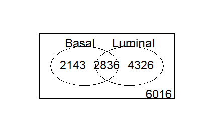

```r
venn_data <- data.frame(Basal = results(de_basal)$padj < 0.05, Luminal  = results(de_luminal)$padj<0.05)

vennDiagram(venn_data)
```

The multi-factor uses all samples, but includes a factor for the `CellType`. We can still extract results for virgin vs lactation, but these are corrected for differences in `CellType`.

```r
dds_mf <- dds
dds_mf$Status <- as.factor(dds_mf$Status)
design(dds_mf) <- ~CellType+Status
de_mf <- DESeq(dds_mf)
```

```
using 'avgTxLength' from assays(dds), correcting for library size
```

```r
results_mf <- results(de_mf,contrast=c("Status","virgin","lactation"
                                       ))
results_mf
```

```
log2 fold change (MLE): Status virgin vs lactation
Wald test p-value: Status virgin vs lactation
DataFrame with 34452 rows and 6 columns
                    baseMean log2FoldChange     lfcSE      stat    pvalue
                   <numeric>      <numeric> <numeric> <numeric> <numeric>
ENSMUSG00000000001  4068.373       0.158458  0.113249  1.399206  0.161751
ENSMUSG00000000003     0.000             NA        NA        NA        NA
ENSMUSG00000000028   203.513       0.465279  0.536830  0.866716  0.386098
ENSMUSG00000000037   121.277       0.126304  0.408336  0.309315  0.757082
ENSMUSG00000000049     2.100       1.060940  1.310861  0.809346  0.418316
...                      ...            ...       ...       ...       ...
ENSMUSG00000115841   0.00000             NA        NA        NA        NA
ENSMUSG00000115843   0.00000             NA        NA        NA        NA
ENSMUSG00000115844   0.00000             NA        NA        NA        NA
ENSMUSG00000115847   0.00000             NA        NA        NA        NA
ENSMUSG00000115848   1.48226       0.303282   1.34694  0.225164  0.821852
                        padj
                   <numeric>
ENSMUSG00000000001  0.303991
ENSMUSG00000000003        NA
ENSMUSG00000000028  0.556337
ENSMUSG00000000037  0.853480
ENSMUSG00000000049        NA
...                      ...
ENSMUSG00000115841        NA
ENSMUSG00000115843        NA
ENSMUSG00000115844        NA
ENSMUSG00000115847        NA
ENSMUSG00000115848        NA
```

Using a filter we can identify the genes from this analysis. We can see that many more genes identified, so in this case it is better to include all samples and model the difference in `CellType`.

```r
filter(data.frame(results_mf), padj < 0.05)
```

|  | baseMean | log2FoldChange | lfcSE | stat | pvalue | padj |
| --- | --- | --- | --- | --- | --- | --- |
| ENSMUSG00000000058 | 3.647180e+03 | -1.6164472 | 0.35347716 | -4.572989 | 4.808151e-06 | 6.088252e-05 |
| ENSMUSG00000000078 | 3.598097e+04 | -0.8353165 | 0.19651455 | -4.250660 | 2.131418e-05 | 2.194414e-04 |
| ENSMUSG00000000126 | 4.842911e+01 | 1.4735624 | 0.42950344 | 3.430851 | 6.016907e-04 | 3.731668e-03 |
| ENSMUSG00000000127 | 5.326314e+02 | -0.5848159 | 0.13504012 | -4.330683 | 1.486479e-05 | 1.610367e-04 |
| ENSMUSG00000000142 | 1.191528e+02 | 1.4848145 | 0.46385691 | 3.201018 | 1.369428e-03 | 7.341099e-03 |
| ENSMUSG00000000149 | 1.142166e+03 | 0.6346344 | 0.22136215 | 2.866951 | 4.144476e-03 | 1.809077e-02 |
| ENSMUSG00000000168 | 2.825812e+03 | -1.9428367 | 0.50025568 | -3.883687 | 1.028842e-04 | 8.434590e-04 |
| ENSMUSG00000000197 | 6.289843e+01 | 2.1614798 | 0.76228094 | 2.835542 | 4.574797e-03 | 1.960977e-02 |
| ENSMUSG00000000204 | 1.076465e+01 | 2.1584651 | 0.86171672 | 2.504843 | 1.225057e-02 | 4.263993e-02 |
| ENSMUSG00000000282 | 6.672591e+02 | 0.7253074 | 0.22235247 | 3.261971 | 1.106403e-03 | 6.179170e-03 |

[output cut: 990 more lines]